# 1-phase controlled rectifier

A phase-controlled converter is shown below with $v_s(t)=220\sqrt2\,\sin(\omega \,t)$. The thyristor is fired at an angle $30^\circ$ in every positive half cycle of the input voltage. Determine the average current through the $R$-$L$ load.

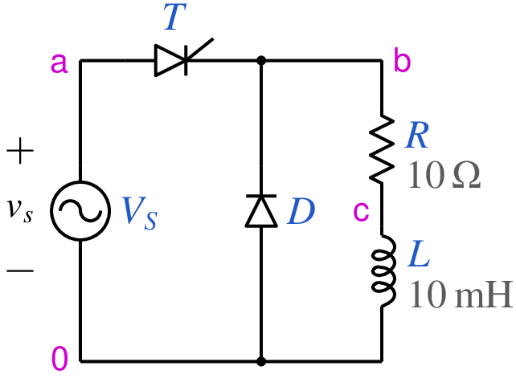

```python
from IPython.display import Image
Image(filename =r'controlled_rectifier_1ph_3_fig_1.png', width=270)
```

```python
# run this cell to view the circuit file.
%pycat controlled_rectifier_1ph_3_orig.in
```

We now replace the strings such as `\$R` with the values of our choice by running the python script given below. It takes an existing circuit file `controlled_rectifier_1ph_3_orig.in` and produces a new circuit file `controlled_rectifier_1ph_3.in`, after replacing `\$R` (etc) with values of our choice.

```python
import gseim_calc as calc
import numpy as np

s_R = "10"
s_L = "10e-3"
s_alpha = "30"

l = [
  ('$R', s_R),
  ('$L', s_L),
  ('$alpha', s_alpha),
]
calc.replace_strings_1("controlled_rectifier_1ph_3_orig.in", "controlled_rectifier_1ph_3.in", l)
print('controlled_rectifier_1ph_3.in is ready for execution')
```

```
controlled_rectifier_1ph_3.in is ready for execution
```

**Execute the following cell to run GSEIM on controlled_rectifier_1ph_3.in.**

```python
import os
import dos_unix
# uncomment for windows:
#dos_unix.d2u("controlled_rectifier_1ph_3.in")
os.system('run_gseim controlled_rectifier_1ph_3.in')
```

```
Circuit: filename = controlled_rectifier_1ph_3.in
main: calling solve_sss
solve_sss starting: sss_n_st: 1
solve_sss_ex: sss_iter_newton=0, rhs_sss_norm=4.4434e-04, sss_period_1_compute=4.0000e-02
solve_sss_ex: sss_iter_newton=1, rhs_sss_norm=0.0000e+00, sss_period_1_compute=4.0000e-02
solve_sss_ex: calling sss_solve_trns_ex for one more trns step
Transient simulation starts...
i=0
i=1000
i=2000
GSEIM: Program completed.
```

```
0
```

The circuit file (`controlled_rectifier_1ph_3.in`) is created in the same directory as that used for launching Jupyter notebook. The last step (i.e., running `GSEIM` on `controlled_rectifier_1ph_3.in`) creates a data file called `controlled_rectifier_1ph_3.dat` in the same directory. We can now use the python code below to compute/plot the various quantities of interest.

```
filename: controlled_rectifier_1ph_3.dat
average load current:  9.2310E+00
```

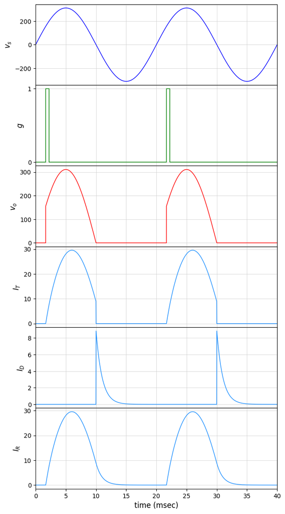

```python
import numpy as np
import matplotlib.pyplot as plt
import gseim_calc as calc
from setsize import set_size

f_hz = 50.0
T = 1.0/f_hz

slv = calc.slv("controlled_rectifier_1ph_3_orig.in")

i_slv = 0
i_out = 0
filename = slv.l_filename_all[i_slv][i_out]
print('filename:', filename)
u = np.loadtxt(filename)
t = u[:, 0]

v_s = slv.get_array_double(i_slv,i_out,"v_s",u)
v_o = slv.get_array_double(i_slv,i_out,"v_o",u)
g   = slv.get_array_double(i_slv,i_out,"g",u)
IT   = slv.get_array_double(i_slv,i_out,"IT",u)
ID   = slv.get_array_double(i_slv,i_out,"ID",u)
IR   = slv.get_array_double(i_slv,i_out,"IR",u)

l_IR = calc.avg_rms_3a(t, IR, 0.0, 2.0*T, 1.0e-5*T)

print('average load current:', "%11.4E"%l_IR[0])

color1='blue'
color2='green'
color3='red'
color4='dodgerblue'

fig, ax = plt.subplots(6, sharex=False)
plt.subplots_adjust(wspace=0, hspace=0.0)

set_size(5.5, 11, ax[0])

for i in range(6):
    ax[i].set_xlim(left=0.0, right=2.0*T*1e3)
    ax[i].grid(color='#CCCCCC', linestyle='solid', linewidth=0.5)

ax[0].set_ylabel(r'$v_s$', fontsize=12)
ax[1].set_ylabel(r'$g$'  , fontsize=12)
ax[2].set_ylabel(r'$v_o$', fontsize=12)
ax[3].set_ylabel(r'$I_T$', fontsize=12)
ax[4].set_ylabel(r'$I_D$', fontsize=12)
ax[5].set_ylabel(r'$I_R$', fontsize=12)

ax[1].set_yticks([0.0, 1.0])

for k in range(5):
    ax[k].tick_params(labelbottom=False)

ax[0].plot(t*1e3, v_s, color=color1, linewidth=1.0, label="$v_s$")
ax[1].plot(t*1e3, g  , color=color2, linewidth=1.0, label="$g$")
ax[2].plot(t*1e3, v_o, color=color3, linewidth=1.0, label="$v_o$")
ax[3].plot(t*1e3, IT , color=color4, linewidth=1.0, label="$I_T$")
ax[4].plot(t*1e3, ID , color=color4, linewidth=1.0, label="$I_D$")
ax[5].plot(t*1e3, IR , color=color4, linewidth=1.0, label="$I_R$")

ax[5].set_xlabel('time (msec)', fontsize=12)

#plt.tight_layout()
plt.show()
```

This notebook was contributed by **Prof. Nakul Narayanan K**, Govt. Engineering College, Thrissur. He may be contacted at nakul@gectcr.ac.in.